### Garbowski - 2017 CPNPP Traits

**The situation:** These data were collected to assess variation within and among species that the Bureau of Land Management (Colorado Plateau Native Plant Program) is interested in developing for restoraiton. The data were not intended to answer any specific reasearch questions. Still, I hope they can be used to answer some “retroactive” questions.

**The data:** The data were collected from 11 native species (3-6 populations of each) at four timepoints: 10 days old, 24 days old, 42 days old, and 84 days old. At each sampling timepoint, on average, four individuals per species per population were measured. Everything was grown in greenhouse conditions and all indidivudals of a given species were seeded at more or less the same time. For slow growing species the 10-day measurements are problematic (lots of zeors) and for most species, but especially fast growing ones, the 84-day measurements are problematic because plants became quite root bound in pots (84-day data not included here). The associated data set (Garbowski_Traits2017_HECO_ELTR_PLPA_VUOC.csv) has four of the 11 species in it.

**Current approach:** So far I’ve been exploring differences in trait means (and variances in STAN but struggling to extract variance measures in JAGS) within and among populations of individual species at individual time points.

**Goals/What I’d appreciate help with (1 -3, maybe 4 down the road).**  
**Technical:**

1. How can I model variance (sigma or tau) from each population in JAGS? I have this figured out in STAN but can’t seem to get it here. If this question is still here but the time I send this, than I did not figure it out.
2. How can I include sampling date (harvest time, “H_num”" or “Days” in the data file) into my model so differencs can be compared within/among population(s) but at different times?
3. Check on model(s) currently being used
   - Do priors/distributions seem appropriate?
   - Since I’ll mostly be working with positive continous traits (even those that fall between 0-1), I can use the same model over and over again. Correct? Should I also be using the same priors each time?
4. Evenutally…How to compare among species?

**Conceptual (Ideas towards chapters/papers):**

1. Id like to assess within species variation using data I’ve collected and compare it to data available in TRY. Mitchell, R. M. and J.D. Bakker (2013) Functional Ecology do this with *Hypochaeris radicata*. I suspect this would result in a pretty discriptive paper with a central research question along the lines of “Are publically available trait values reflective of seedling trait values from multiple populations”?. I would probably only focus on one or two traits that seem to be the most popular and for which values are available in TRY (e.g. SLA?) **Does this seem reasonable?**
2. I’d like to compare trait means and variances among sampling dates within populations or species. How do individual traits (and maybe trait correlations?) change through time for a given population/species. To look at correlations, I think I would need lump trait values together across populations at sampling timepoints. Four measures/timepoint doesn’t seem like enough. If I were to combine measures within a species, I would have ~16-20 samples/timepoint which still may not be enough. **Are correlations among traits likely to change with ontogeny? I’m familiar with your Ecology and Evolution (2017) paper do you have any other recommendations for reading/background?**

Below are examples of my appraoches so far (translated to the best of my ability from STAN to JAGS). I am still “hacking” to try to get things to work and when something does work I cross my fingers and hope I’m not making too many serious mistakes.

##### Load data and packages

```r
#Load packages
library(ggplot2)
library(rjags)
library(parallel)
library(runjags)
library(reshape)
library(coda)
library(knitr)

# Load data
Trait2017_data<-read.csv("/Users/MagdaGarbowski/Traits_2017_Grasses/HECO_ELTR_PLPA_VUOC.csv")
# Subset Heterostipa comata (HECO)
HECO_data<-Trait2017_data[Trait2017_data$SPECIES=="HECO",]
# Create integer index for POP_NUM
HECO_data$POP_ID.index<-as.integer(
  factor(HECO_data[,c("POP_ID")],levels=c("HECO_AZNC_KV","HECO_UTC_KRR","HECO_UTC_TMR","HECO_UTEC_GR","HECO_UTSW_SP")))
HECO_data<-HECO_data[complete.cases(HECO_data), ]
kable(head(HECO_data))
```

|  | X | SAMPLE_ID | SumOfLength.cm. | SumOfAvgDiam.mm. | H_num | HT | LWD | RWD | POP_ID | Days | SPECIES | SLA.TOT | S.RL | TotWD | RMR | TotLDW | LDMC | POP_ID.index |
| --- | --- | --- | --- | --- | --- | --- | --- | --- | --- | --- | --- | --- | --- | --- | --- | --- | --- | --- |
| 2 | 2 | HECO_AZNC_KV_3_H3_G | 238.5084 | 0.23490 | 3 | 18.9 | 0.0281 | 0.0104 | HECO_AZNC_KV | 42 | HECO | 14.301419 | 43.60433 | 0.0385 | 0.2701299 | 0.0281 | 0.2849899 | 1 |
| 3 | 3 | HECO_AZNC_KV_4_H2_G | 178.0716 | 0.26100 | 2 | 11.5 | 0.0060 | 0.0081 | HECO_AZNC_KV | 24 | HECO | 14.726095 | 45.48732 | 0.0165 | 0.4909091 | 0.0084 | 0.3054545 | 1 |
| 4 | 4 | HECO_AZNC_KV_4_H2_O | 185.7397 | 0.25640 | 2 | 12.0 | 0.0087 | 0.0082 | HECO_AZNC_KV | 24 | HECO | 15.542653 | 44.14780 | 0.0194 | 0.4226804 | 0.0112 | 0.3137255 | 1 |
| 5 | 5 | HECO_AZNC_KV_6_H1_O | 17.1005 | 0.43960 | 1 | 9.6 | 0.0036 | 0.0026 | HECO_AZNC_KV | 10 | HECO | 4.975881 | 152.04234 | 0.0078 | 0.3333333 | 0.0052 | 0.2441315 | 1 |
| 6 | 6 | HECO_AZNC_KV_6_H1_G | 11.4878 | 0.44850 | 1 | 7.7 | 0.0032 | 0.0028 | HECO_AZNC_KV | 10 | HECO | 5.352692 | 243.73683 | 0.0068 | 0.4117647 | 0.0040 | 0.2816901 | 1 |
| 7 | 7 | HECO_AZNC_KV_7_H3_G | 245.0309 | 0.63075 | 3 | 12.3 | 0.0086 | 0.0047 | HECO_AZNC_KV | 42 | HECO | 3.208105 | 19.18125 | 0.0133 | 0.3533835 | 0.0086 | 0.4095238 | 1 |

#### Model with estimates of mu (intercepts) for each population.

Measurements from ALL sample points are being lumped together

```r
y.POP.n = length(unique(HECO_data$POP_ID)) # This is being difficult in the data call. Magda: fix this.
# Input Data
data = list(
  y.SLA = (HECO_data$SLA.TOT),
  y.POP.group = HECO_data$POP_ID.index,
  y.POP.n = length(unique(HECO_data$POP_ID)),
  n = nrow(HECO_data))

# Initial conditions

inits = list(
  list(
    mu_group = rep(5, y.POP.n),
    sigma = 10,
    mu_log = 0,
    sigma_log = .5
  ),
  list(
    mu_group = rep(10, y.POP.n),
    sigma = 15,
    mu_log = 1,
    sigma_log = 1
  )
)

{
  sink("Individual_POPS_JAGS.R")
  cat("
    model{
# Priors

  sigma ~ dunif (0,60)

  mu_log ~ dnorm(0, 0.001)
  sigma_log ~ dunif(0,60)

  mu_y= exp(mu_log+sigma_log^2/2)
  sigma_y = sqrt(exp(2*mu_log+sigma_log^2)*(exp(sigma_log^2)-1))
  tau_y = 1/(sigma_y^2)

# Likelihood
      for(i in 1:n){
      mu[i] = mu_group[y.POP.group[i]]
      y.SLA[i] ~ dnorm(mu[i], tau_y) }
for (j in 1:y.POP.n){ #set loop to cycle through POPS
        mu_group[j]~dlnorm(mu_y,tau_y)
}}
  ", fill=T)
  sink()
}

# Write JAGS model and run
out.individual.SLA = run.jags(model="Individual_POPS_JAGS.R", method="rjparallel",
               monitor=c("mu_group"),
               data=data, n.chains=2, inits=inits,
               adapt=250, burnin=250, sample=5000, thin=1)
```

```
## Compiling rjags model...
## Starting 2 rjags simulations using a Fork cluster with 2 nodes on
## host 'localhost'
## Simulation complete
## Calculating summary statistics...
## Calculating the Gelman-Rubin statistic for 5 variables....
## Finished running the simulation
```

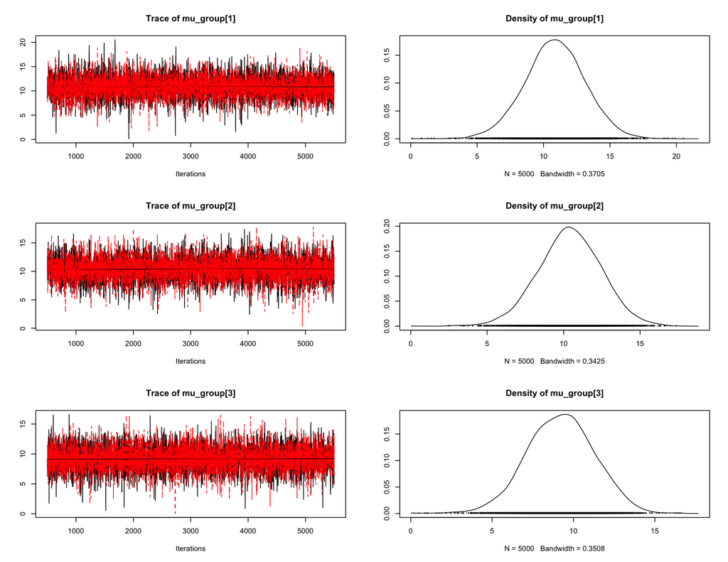

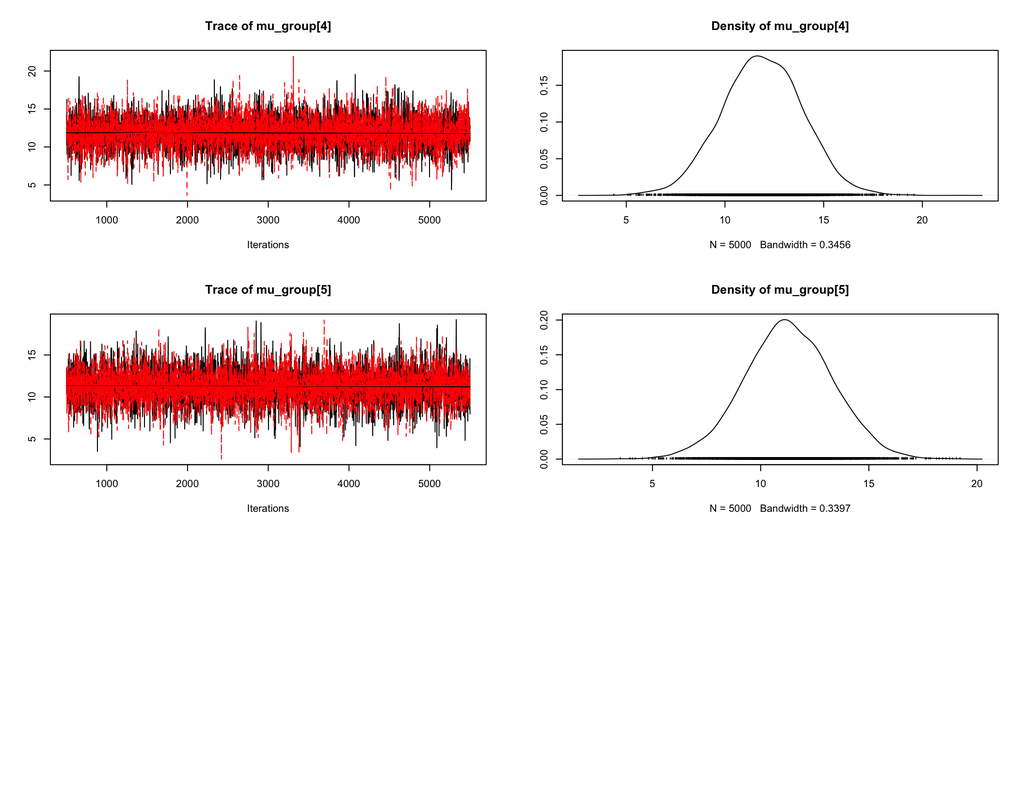

```r
output.individual.SLA <- summary(out.individual.SLA$mcmc)
#Produce trace plots of the chains for model parameters
plot(out.individual.SLA$mcmc)
```

```r
#Produce a summary table for the parameters
as.data.frame(output.individual.SLA$statistics)
```

```
##                  Mean       SD   Naive SE Time-series SE
## mu_group[1] 10.851093 2.288212 0.02288212     0.02811350
## mu_group[2] 10.393124 2.077688 0.02077688     0.02695170
## mu_group[3]  9.207019 2.088260 0.02088260     0.02636076
## mu_group[4] 11.884907 2.057209 0.02057209     0.02640003
## mu_group[5] 11.279411 2.043247 0.02043247     0.02598820
```

```r
#Test for convergence using the Gelman diagnostic
gelman.diag(out.individual.SLA$mcmc)
```

```
## Potential scale reduction factors:
##
##             Point est. Upper C.I.
## mu_group[1]          1       1.00
## mu_group[2]          1       1.01
## mu_group[3]          1       1.00
## mu_group[4]          1       1.01
## mu_group[5]          1       1.00
##
## Multivariate psrf
##
## 1
```

```r
#Check against "regular" means
HECO_SLA<-HECO_data[, c("POP_ID","SLA.TOT" )]
aggregate(HECO_SLA[,2], list(HECO_SLA$POP_ID), mean)
```

```
##        Group.1         x
## 1 HECO_AZNC_KV 11.318291
## 2 HECO_UTC_KRR 10.828878
## 3 HECO_UTC_TMR  9.663238
## 4 HECO_UTEC_GR 12.261590
## 5 HECO_UTSW_SP 11.572177
```

SUBSET of data at 24-day measurement. It would be GREAT to not do this and have all data from a species in the same model. I assume I need to let the “slopes” vary by time (H_num) H_num stands for harvest number.

```r
HECO_24Day_data<-HECO_data [(HECO_data$Days%in%c("24")), ]

y.POP.n = length(unique(HECO_24Day_data$POP_ID)) # This is being difficult in the data = list. Magda: fix this.
# Input Data
data = list(
  y.SLA = (HECO_24Day_data$SLA.TOT),
  y.POP.group = HECO_24Day_data$POP_ID.index,
  y.POP.n = length(unique(HECO_24Day_data$POP_ID)),
  n = nrow(HECO_24Day_data))

# Initial conditions

inits = list(
  list(
    mu_group = rep(5, y.POP.n),
    sigma = 10,
    mu_log = 0,
    sigma_log = .5
  ),
  list(
    mu_group = rep(10, y.POP.n),
    sigma = 15,
    mu_log = 1,
    sigma_log = 1
  )
)

{
  sink("Individual_POPS_JAGS.R")
  cat("
    model{
# Priors

  sigma ~ dunif (0,60)

  mu_log ~ dnorm(0, 0.001)
  sigma_log ~ dunif(0,60)

  mu_y= exp(mu_log+sigma_log^2/2)
  sigma_y = sqrt(exp(2*mu_log+sigma_log^2)*(exp(sigma_log^2)-1))
  tau_y = 1/(sigma_y^2)

# Likelihood
      for(i in 1:n){
      mu[i] = mu_group[y.POP.group[i]]
      y.SLA[i] ~ dnorm(mu[i], tau_y) }
for (j in 1:y.POP.n){ #set loop to cycle through POPS
        mu_group[j]~dlnorm(mu_y,tau_y)
}}
  ", fill=T)
  sink()
}

# Write JAGS model and run
out.individual.SLA = run.jags(model="Individual_POPS_JAGS.R", method="rjparallel",
               monitor=c("mu_group"),
               data=data, n.chains=2, inits=inits,
               adapt=250, burnin=250, sample=5000, thin=1)
```

```
## Compiling rjags model...
## Starting 2 rjags simulations using a Fork cluster with 2 nodes on
## host 'localhost'
## Simulation complete
## Calculating summary statistics...
## Calculating the Gelman-Rubin statistic for 5 variables....
## Finished running the simulation
```

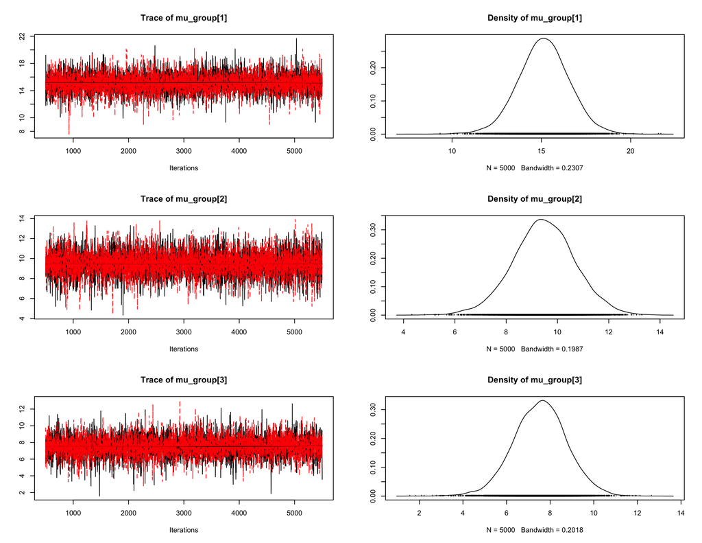

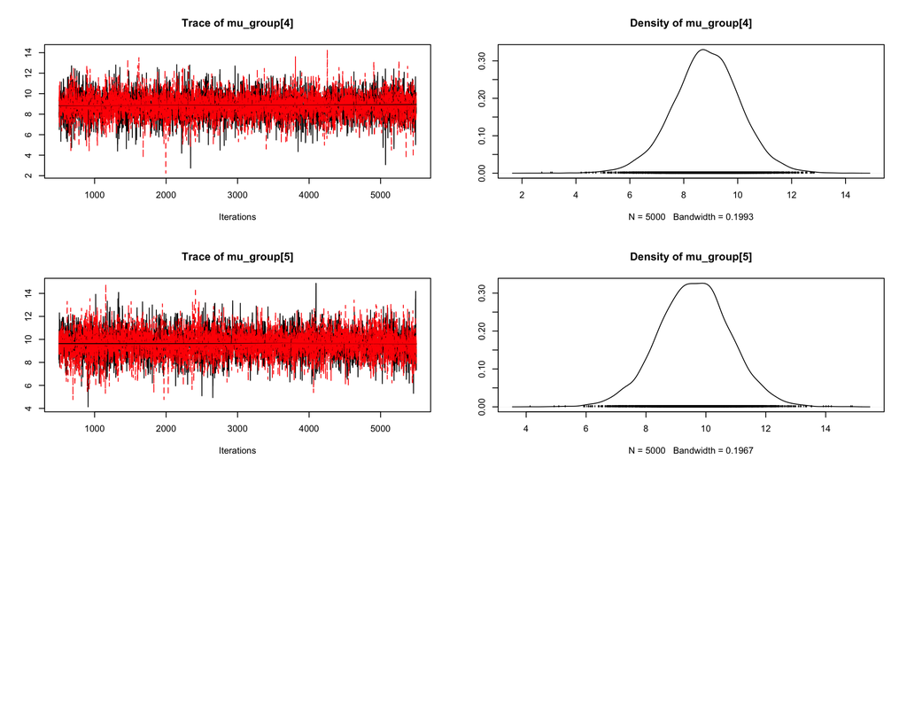

```r
output.individual.SLA <- summary(out.individual.SLA$mcmc)
#Produce trace plots of the chains for model parameters
plot(out.individual.SLA$mcmc)
```

```r
#Produce a summary table for the parameters
as.data.frame(output.individual.SLA$statistics)
```

```
##                  Mean       SD   Naive SE Time-series SE
## mu_group[1] 15.127370 1.428713 0.01428713     0.01891261
## mu_group[2]  9.468047 1.219783 0.01219783     0.01608490
## mu_group[3]  7.537545 1.233688 0.01233688     0.01649408
## mu_group[4]  8.846168 1.254001 0.01254001     0.01608675
## mu_group[5]  9.615511 1.207112 0.01207112     0.01549368
```

```r
#Test for convergence using the Gelman diagnostic
gelman.diag(out.individual.SLA$mcmc)
```

```
## Potential scale reduction factors:
##
##             Point est. Upper C.I.
## mu_group[1]          1       1.00
## mu_group[2]          1       1.00
## mu_group[3]          1       1.01
## mu_group[4]          1       1.00
## mu_group[5]          1       1.00
##
## Multivariate psrf
##
## 1
```

```r
#Check against "regular" means
HECO_SLA<-HECO_24Day_data[, c("POP_ID","SLA.TOT" )]
aggregate(HECO_SLA[,2], list(HECO_SLA$POP_ID), mean)
```

```
##        Group.1         x
## 1 HECO_AZNC_KV 15.297810
## 2 HECO_UTC_KRR  9.654385
## 3 HECO_UTC_TMR  7.742576
## 4 HECO_UTEC_GR  9.019381
## 5 HECO_UTSW_SP  9.798478
```